# Model the Iris Data (Linear Regression)

# 1) Linear Regression Model

## Create a WIDE TABLE Format

FOR EACH Observation 1) Add flower # as a variable 2) have the PART of the flower as a categorical variable 3) get the LENGTH and WIDTH as the two variable with numerical values in them

TIDY Data Each column a VARIABLE; Each row an OBSERVATION; Each cell a VALUE;

```r
wide_iris <- iris %>%
  gather(key='key', value='value', -Species, -Flower) %>%
  separate(key, c('Part','Measure'), sep= "\\.") %>%
  spread(Measure, value)
wide_iris
```

|  | Species | Flower | Part | Length | Width |
| --- | --- | --- | --- | --- | --- |
| 1 | setosa | 1 | Petal | 1.4 | 0.2 |
| 2 | setosa | 1 | Sepal | 5.1 | 3.5 |
| 3 | setosa | 2 | Petal | 1.4 | 0.2 |
| 4 | setosa | 2 | Sepal | 4.9 | 3.0 |
| 5 | setosa | 3 | Petal | 1.3 | 0.2 |
| 6 | setosa | 3 | Sepal | 4.7 | 3.2 |
| 7 | setosa | 4 | Petal | 1.5 | 0.2 |
| 8 | setosa | 4 | Sepal | 4.6 | 3.1 |
| 9 | setosa | 5 | Petal | 1.4 | 0.2 |
| 10 | setosa | 5 | Sepal | 5.0 | 3.6 |

[output cut: 290 more lines]

### Explanation

http://r4ds.had.co.nz/tidy-data.html#spreading-and-gathering gather() - select a key which is the NAME OF THE COLUMNS in the untidy data (current variables) - the value for that variable -keep only SPECIES, FLOWER columns and then the variable being measured (key=) and then value for that observation (value=) separate() -split a column into two -split the key column, into ‘part’ and ‘measure’ at the ‘.’ sign spread() -then spread the measure column into its separate components (length and width) -taking the value column as the valu for each of those cells! WE have tidy data :)

## Build the Linear Model (using ggplot)

NOTE: This analysis was flawed by the fact that I didn’t separate Petal or Sepal when comparing length and width in plot1 & plot3

### Load the ggplot() header

```r
lm_iris <- ggplot(data = wide_iris, mapping= aes(x= Width, y= Length, col=Species))
```

### Compare LENGTH and WIDTH for each species

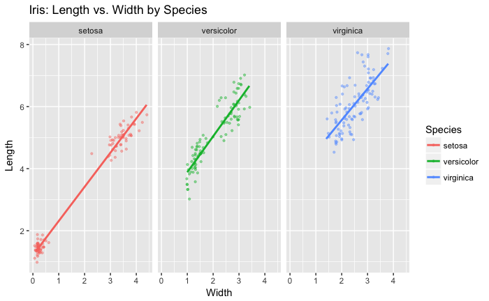

```r
lm_iris1 <- lm_iris+
  geom_jitter(alpha= 0.4, size= 0.8) +
  facet_grid(. ~ Species) +
  stat_smooth(method= 'lm', se=F) +
  ggtitle("Iris: Length vs. Width by Species")
lm_iris1
```

### Compare Petal Length vs. Petal Width & Sepal Width vs. Sepal Length

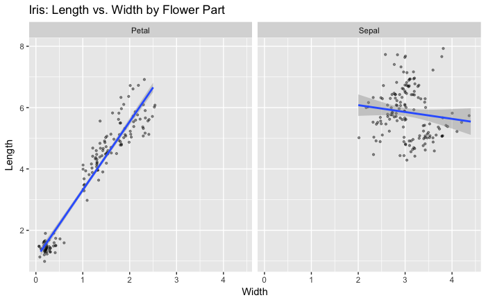

```r
lm_iris2 <- ggplot(data=wide_iris, mapping=aes(x=Width, y=Length)) +
  geom_jitter(alpha=0.4, size=0.8) +
  facet_grid(.~ Part) +
  stat_smooth(method= 'lm', se=T) +
  ggtitle("Iris: Length vs. Width by Flower Part")

lm_iris2
```

### How does length and width compare for each species

NOTE: False Analysis because aggregated Sepals and Petals

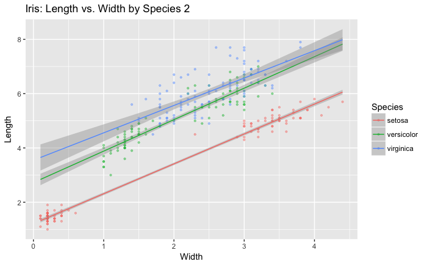

```r
lm_iris3 <- lm_iris +
  geom_point(alpha = 0.4, size= 0.8) + stat_smooth(method = 'lm', fullrange= T, size= 0.5) +
  ggtitle("Iris: Length vs. Width by Species 2")

lm_iris3
```